# Chi-square and non-parametric tests

You should work through the exercises step-by-step, following the instructions carefully. At various points we will interrupt the flow of instructions with a question. Make a note of your answers so that you can complete the MOLE quiz for this week.

### Oviposition behaviour in bean weevils

The bean weevil, *Callosobruchus maculatus*, lays its eggs on the surface of legume seeds such as black-eyed beans and aduki beans. In an experiment to test whether female *Callosobruchus* are selective in the type of beans on which they oviposit, choice tests were carried out. In each, a single newly mated female was introduced into an experimental arena containing one each of 5 bean types. The bean on which the first egg was laid was recorded. The test was repeated 45 times with a different beetle each time.

| Bean type | Aduki | Black-eyed | Kidney | Haricot | Pinto |
| --- | --- | --- | --- | --- | --- |
| Number of times chosen | 6 | 16 | 10 | 8 | 5 |

Construct a data frame containing these data. It needs to have two columns: `Bean` should contain the bean type, and `Frequency` should contain the number of times the bean was chosen. Make the following bar plot to summarise them:

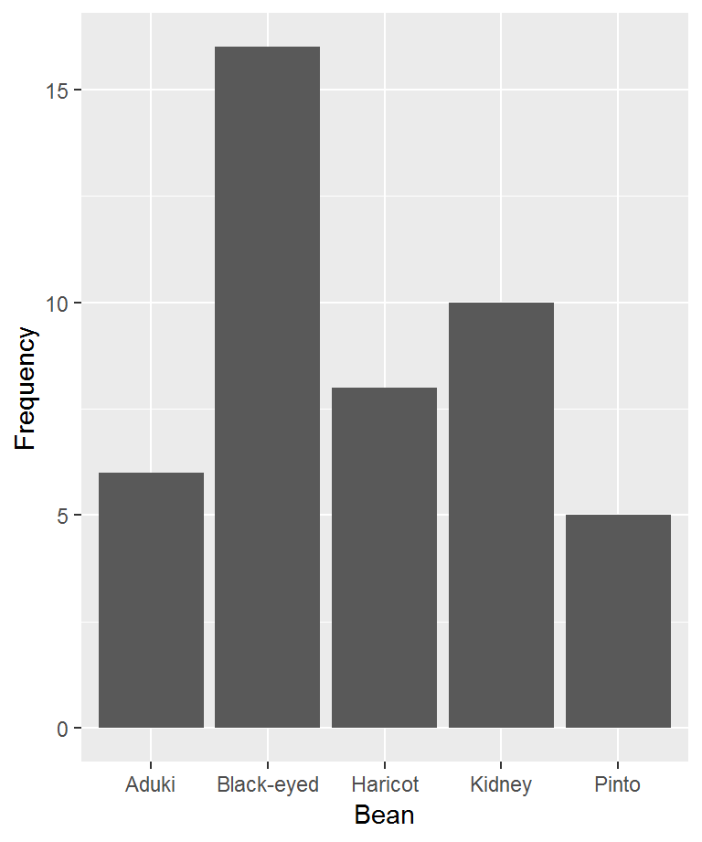

Carry out an appropriate test to determine whether *Callosobruchus* are selective in the type of beans on which they oviposit.

**MOLE question**

Summarise the results from the test.

### Determining expected values

What might be an appropriate way to obtain a set of expected frequencies for an ornithologist who wants to analyse data on observations of great tits foraging to see if they prefer to forage in particular tree species? Imagine that along a transect through a wood a record was made every time a great tit was seen and of the tree species in which it was foraging…

**MOLE question**

What, if any, additional data would this require the ornithologist to collect?

### Sex and eye colour

Let’s return to the initial example used to illustrate a contingency table, we might want to ask if there is an association between eye colour and sex. Data in the file CLASS.CSV show a number of attributes measured from a sample of APS students from a few years ago. Each row contains observations from one student. The two variables we are interested in here are `Sex` (values: ‘Female’ and ‘Male’) and `Eye` (values: ‘Blue’, ‘Brown’ and ‘Green’).

Carry out a $\chi^{2}$ test to determine whether eye colour and sex are associated in this sample.

**MOLE question**

What do you conclude about the association between sex and eye colour?

### Eagle owls and prey choice

There are many situations which may produce tables larger than a 2 x 2 contingency table. For example, we could have used the same experimental procedure as in the *Callosobruchus* experiment given earlier but looked at bean choice for 5 sets of females each of which had themselves been reared on a different bean type to see if selection of oviposition site is influenced by the bean type the female developed on.

In fact we are going to look at prey choice between male and female eagle owls. You will recall that the prey of eagle owls can be established by examination of the pellets containing the undigested remains of their prey. In the eagle owl study the diets of the male and female of a pair were studied by examination of the pellets collected from beneath their roosts (fortunately, an individual tends to use the same roosting site, and individuals tend not to roost together). The numbers of all prey types found in the pellets were recorded.

These data are in the file EAGLES.CSV. Read these data into R and inspect them to ensure you understand how they are organised. Once you understand the data, see if you can make the following bar plot to summarise them:

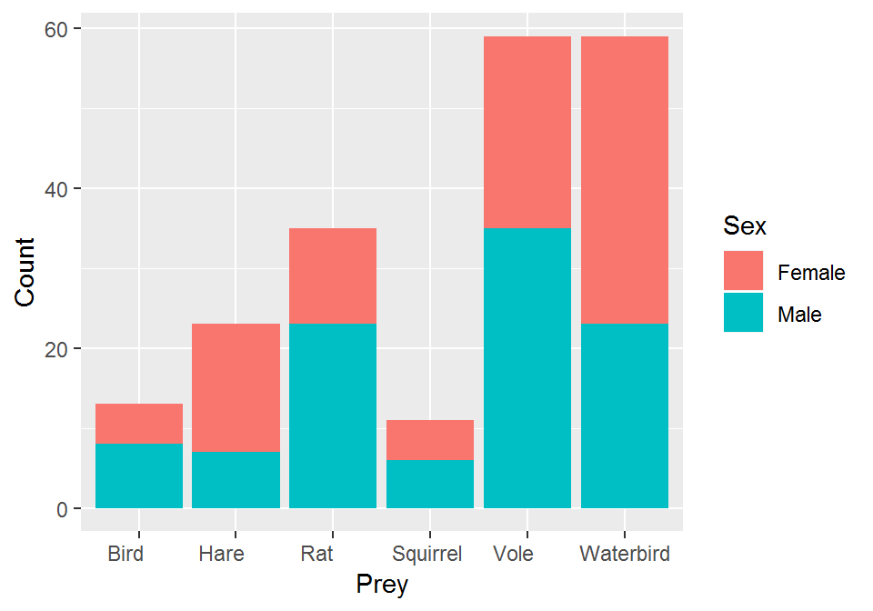

Analyse whether there is any evidence of differences in the diets of the male and female eagle owls.

**MOLE question**

What do you conclude?

**MOLE question**

If there is an effect, what might account for the result?

### Reporting the results of non-parametric tests

**MOLE question**

You might sometimes see a statements such as:

> The means were significantly different (Mann-Whitney *U*-test: U=43, n<sub>1</sub>=14, n<sub>2</sub>=14, *p*<0.05).

What is wrong with this?

### Copper tolerance in *Agrostis*

A study was carried out to examine how quickly copper tolerance is acquired in the grass *Agrostis stolonifera* growing on copper contaminated soil. Plants from two lawns, planted 8 years and 14 years ago, around the buildings of a copper refinery, were tested for copper tolerance by growing them in a standard liquid culture medium with elevated levels of copper. Root extension (in mm) was measured for each plant over a 14 day period.

The data are in the file LAWNS.CSV. There are two variables: `Roots` contains the measured root extension and `Lawn` identifies the two groups (years of exposure). Read these data into R, calling the data frame `copperlawn`. Examine the data with `View`.

Have a look at the distributions of the data (using histograms, dot plots, or whatever method you think best).

With 10 and 15 values it is, as always, hard to tell whether or not the data are drawn from a normally distributed population, although they don’t look particularly normal. However, consideration of the nature of the data might also lead us to be cautious. Copper contamination may be patchy in the lawn, so there may be a mixture of more and less tolerant individuals, and depending on the nature of the genetic control of tolerance, it may have a distribution that is not clearly unimodal. In this case, it doesn’t look as though a transformation is obviously going to help, and although we might be prepared to risk a parametric test, a non-parametric test is safer.

Use an appropriate non-parametric test to evaluate whether root growth, in culture solution, differs between plants from the two lawns.

**MOLE question**

Summarise the conclusion from the test and think about what the results suggest.

### Measuring seed dispersal

An investigator was interested in the dispersal abilities of a number of plant species which reinvade disturbed ground by means of windborne seed. To try and measure the seed influx they put out a tray of sterilised potting soil at each of 10 locations around a newly disturbed site. Each week for 11 weeks they remove the trays and replace them with new ones. The collected trays are covered and brought into a glasshouse where any seeds they contain are allowed to germinate. From this procedure they know for each plant species the week (1-11) when it first appeared at each location - a value of 12 is given to any species that didn’t arrive at a location by the end of the experiment. You can use these data to test whether, for the four plant species studied, there is any significant difference in dispersal rates between species.

The data are in the file DISPERSAL.CSV. There are two variables: `Week` contains the arrival week and `Species` identifies the four species (‘A’ - ‘D’). Read these data into R, examine them with `View`, and make an informative plot.

Once you understand the data, use an appropriate non-parametric test to evaluate whether the four species differ significantly in dispersal ability (at least as measured by speed of colonisation).

**MOLE question**

Write a statistically supported conclusion from the test:

### Analysing associations

Consider the following scenarios and decide whether the data are suitable for linear regression, Pearson’s product-moment correlation or neither:

- Shoe size and height of students in a class. We want to know if shoe size is associated with the height of male students in a class. We measure the shoe size and height from 120 students. You may assume that shoe size is (approximately) measured onn an interval scale.
- Heart rate and age in the crustacean *Daphnia* reared in the lab. We want to know how, on average, heart rate depends on age. Six groups of 10 *Daphnia* are reared to ages 2, 4, 6, 8, 10, 12 days old. The heart rate of each individual is then assayed at their target age.
- Number of plant species and number of herbivorous insect species. We want to know if the diversity of herbivorous insect species is positively associated with plant diversity. 22 randomly located 5x5m study plots were surveyed in a field.
- Order of arrival of dung beetle species on elephant dung and body size. We want to know if larger dung beetle species are better at locating dung. We locate a fresh piece of dung and observe beetles arriving over a period of 3 hours, recording the order of arrival and the weight of each new arrival.
- Percentage bud damage to pear trees by bullfinches. We want to know how much bud damage changes with the distance of trees from thick vegetation at the edge of an orchard (bullfinches aggregate in the thick vegetation). Trees are arranged in rows parallel to the orchard edge and a single tree, selected at random from every row, is sampled for bud damage.
- Density of nesting stork pairs and number of human births. A science reporter from the Daily Mail is struggling to come up with a story. They think storks might deliver babies, so they collect local hospital records of annual births and amateur ornithology records of number of stork sitings covering a 20 year period in the Sheffield area.
- Colour of the waterbug *Sigara falleni* from a series of ponds and colour of the sediment from each pond. We want to know if the colour of the waterbug *Sigara falleni* (ranked from dark to light) is related to the colour of the sediment (ranked on the same scale) from each pond.
- Number of copulations achieved by male elephant seals and dominance. We want to know if higher-ranked males achieve more matings. Rank is established by observing the outcome of aggressive interactions between males and the number of matings is observed over a two week period in the breeding season.

**MOLE question**

Suggest the type of analysis—and the response and predictor variables where relevant—likely to be appropriate in each case. You may assume that if there is a relationship it will be roughly linear over the range considered.